# IMC - TD n°3 : Manipulation des données et apprentissage statistique

Nicolas Derumigny

# Les données

```r
?Prostate
summary(Prostate)
```

```
     lcavol           lweight           age             lbph
 Min.   :-1.3471   Min.   :2.375   Min.   :41.00   Min.   :-1.3863
 1st Qu.: 0.5128   1st Qu.:3.376   1st Qu.:60.00   1st Qu.:-1.3863
 Median : 1.4469   Median :3.623   Median :65.00   Median : 0.3001
 Mean   : 1.3500   Mean   :3.653   Mean   :63.87   Mean   : 0.1004
 3rd Qu.: 2.1270   3rd Qu.:3.878   3rd Qu.:68.00   3rd Qu.: 1.5581
 Max.   : 3.8210   Max.   :6.108   Max.   :79.00   Max.   : 2.3263
      svi              lcp             gleason          pgg45
 Min.   :0.0000   Min.   :-1.3863   Min.   :6.000   Min.   :  0.00
 1st Qu.:0.0000   1st Qu.:-1.3863   1st Qu.:6.000   1st Qu.:  0.00
 Median :0.0000   Median :-0.7985   Median :7.000   Median : 15.00
 Mean   :0.2165   Mean   :-0.1794   Mean   :6.753   Mean   : 24.38
 3rd Qu.:0.0000   3rd Qu.: 1.1787   3rd Qu.:7.000   3rd Qu.: 40.00
 Max.   :1.0000   Max.   : 2.9042   Max.   :9.000   Max.   :100.00
      lpsa
 Min.   :-0.4308
 1st Qu.: 1.7317
 Median : 2.5915
 Mean   : 2.4784
 3rd Qu.: 3.0564
 Max.   : 5.5829
```

# Entrainement à la manipulation de données

```r
Prostate.norm=data.frame(scale(Prostate)) %>% gather(key = Variables, val = Values)
```

```r
filter(Prostate, age > 70)
```

| lcavol | lweight | age | lbph | svi | lcp | gleason | pgg45 | lpsa |
| --- | --- | --- | --- | --- | --- | --- | --- | --- |
| -0.5108256 | 2.691243 | 74 | -1.3862944 | 0 | -1.3862944 | 7 | 20 | -0.1625189 |
| 1.2753628 | 3.037354 | 71 | 1.2669476 | 0 | -1.3862944 | 6 | 0 | 2.0082140 |
| 1.4231083 | 3.657131 | 73 | -0.5798185 | 0 | 1.6582281 | 8 | 15 | 2.1575593 |
| 2.7278528 | 3.995445 | 79 | 1.8794650 | 1 | 2.6567569 | 9 | 100 | 2.5687881 |
| 0.4574248 | 4.524502 | 73 | 2.3263016 | 0 | -1.3862944 | 6 | 0 | 2.8419982 |
| 2.7757088 | 3.524889 | 72 | -1.3862944 | 0 | 1.5581446 | 9 | 95 | 2.8535925 |
| 2.1983351 | 4.050915 | 72 | 2.3075726 | 0 | -0.4307829 | 7 | 10 | 2.9626924 |
| 1.1939225 | 4.780383 | 72 | 2.3263016 | 0 | -0.7985077 | 7 | 5 | 2.9729753 |
| 1.1600209 | 3.341093 | 77 | 1.7491999 | 0 | -1.3862944 | 7 | 25 | 3.0373539 |
| 2.0108950 | 4.433789 | 72 | 2.1222615 | 0 | 0.5007753 | 7 | 60 | 3.3928291 |

[output cut: 3 more lines]

```r
filter(Prostate, gleason == 6 | gleason == 7)
```

| lcavol | lweight | age | lbph | svi | lcp | gleason | pgg45 | lpsa |
| --- | --- | --- | --- | --- | --- | --- | --- | --- |
| -0.579818495 | 2.769459 | 50 | -1.38629436 | 0 | -1.38629436 | 6 | 0 | -0.4307829 |
| -0.994252273 | 3.319626 | 58 | -1.38629436 | 0 | -1.38629436 | 6 | 0 | -0.1625189 |
| -0.510825624 | 2.691243 | 74 | -1.38629436 | 0 | -1.38629436 | 7 | 20 | -0.1625189 |
| -1.203972804 | 3.282789 | 58 | -1.38629436 | 0 | -1.38629436 | 6 | 0 | -0.1625189 |
| 0.751416089 | 3.432373 | 62 | -1.38629436 | 0 | -1.38629436 | 6 | 0 | 0.3715636 |
| -1.049822124 | 3.228826 | 50 | -1.38629436 | 0 | -1.38629436 | 6 | 0 | 0.7654678 |
| 0.737164066 | 3.473518 | 64 | 0.61518564 | 0 | -1.38629436 | 6 | 0 | 0.7654678 |
| 0.693147181 | 3.539509 | 58 | 1.53686722 | 0 | -1.38629436 | 6 | 0 | 0.8544153 |
| -0.776528789 | 3.539509 | 47 | -1.38629436 | 0 | -1.38629436 | 6 | 0 | 1.0473190 |
| 0.223143551 | 3.244544 | 63 | -1.38629436 | 0 | -1.38629436 | 6 | 0 | 1.0473190 |

[output cut: 81 more lines]

```r
filter(Prostate, lpsa > 3 & age < 45)
```

| lcavol | lweight | age | lbph | svi | lcp | gleason | pgg45 | lpsa |
| --- | --- | --- | --- | --- | --- | --- | --- | --- |
| 3.821004 | 3.896909 | 44 | -1.386294 | 1 | 2.169054 | 7 | 40 | 4.684443 |

```r
filter(Prostate, between(age, 50, 55))
```

| lcavol | lweight | age | lbph | svi | lcp | gleason | pgg45 | lpsa |
| --- | --- | --- | --- | --- | --- | --- | --- | --- |
| -0.579818495 | 2.769459 | 50 | -1.386294 | 0 | -1.386294 | 6 | 0 | -0.4307829 |
| -1.049822124 | 3.228826 | 50 | -1.386294 | 0 | -1.386294 | 6 | 0 | 0.7654678 |
| 0.009950331 | 3.267666 | 54 | -1.386294 | 0 | -1.386294 | 6 | 0 | 2.0215476 |
| 2.907447359 | 3.396185 | 52 | -1.386294 | 1 | 2.463853 | 7 | 10 | 5.1431245 |

```r
Prostate %>% arrange(desc(lpsa))
```

| lcavol | lweight | age | lbph | svi | lcp | gleason | pgg45 | lpsa |
| --- | --- | --- | --- | --- | --- | --- | --- | --- |
| 3.471966453 | 3.974998 | 68 | 0.43825493 | 1 | 2.90416508 | 7 | 20 | 5.5829322 |
| 2.882563575 | 3.773910 | 68 | 1.55814462 | 1 | 1.55814462 | 7 | 80 | 5.4775090 |
| 2.907447359 | 3.396185 | 52 | -1.38629436 | 1 | 2.46385324 | 7 | 10 | 5.1431245 |
| 3.821003607 | 3.896909 | 44 | -1.38629436 | 1 | 2.16905370 | 7 | 40 | 4.6844434 |
| 2.830267834 | 3.876396 | 68 | -1.38629436 | 1 | 1.32175584 | 7 | 60 | 4.3851468 |
| 2.532902848 | 3.677566 | 61 | 1.34807315 | 1 | -1.38629436 | 7 | 15 | 4.1295508 |
| 3.246490992 | 4.101817 | 68 | -1.38629436 | 0 | -1.38629436 | 6 | 0 | 4.0298060 |
| 1.562346305 | 3.695110 | 76 | 0.93609336 | 1 | 0.81093022 | 7 | 75 | 3.9936030 |
| 2.807593831 | 4.718052 | 65 | -1.38629436 | 1 | 2.46385324 | 7 | 60 | 3.9843437 |
| 1.731655545 | 3.369018 | 62 | -1.38629436 | 1 | 0.30010459 | 7 | 30 | 3.7123518 |

[output cut: 87 more lines]

```r
Prostate %>% arrange(desc(lcavol))
```

| lcavol | lweight | age | lbph | svi | lcp | gleason | pgg45 | lpsa |
| --- | --- | --- | --- | --- | --- | --- | --- | --- |
| 3.821003607 | 3.896909 | 44 | -1.38629436 | 1 | 2.16905370 | 7 | 40 | 4.6844434 |
| 3.471966453 | 3.974998 | 68 | 0.43825493 | 1 | 2.90416508 | 7 | 20 | 5.5829322 |
| 3.302849259 | 3.518980 | 64 | -1.38629436 | 1 | 2.32727771 | 7 | 60 | 3.6309855 |
| 3.246490992 | 4.101817 | 68 | -1.38629436 | 0 | -1.38629436 | 6 | 0 | 4.0298060 |
| 3.153590358 | 3.516013 | 59 | -1.38629436 | 0 | -1.38629436 | 7 | 5 | 2.7047113 |
| 3.141130476 | 3.263849 | 68 | -0.05129329 | 1 | 2.42036813 | 7 | 50 | 3.3375474 |
| 2.999226163 | 3.849083 | 69 | -1.38629436 | 1 | 1.90954250 | 7 | 20 | 3.2752562 |
| 2.907447359 | 3.396185 | 52 | -1.38629436 | 1 | 2.46385324 | 7 | 10 | 5.1431245 |
| 2.882563575 | 3.773910 | 68 | 1.55814462 | 1 | 1.55814462 | 7 | 80 | 5.4775090 |
| 2.830267834 | 3.876396 | 68 | -1.38629436 | 1 | 1.32175584 | 7 | 60 | 4.3851468 |

[output cut: 87 more lines]

```r
Prostate %>% arrange(desc(lweight))
```

| lcavol | lweight | age | lbph | svi | lcp | gleason | pgg45 | lpsa |
| --- | --- | --- | --- | --- | --- | --- | --- | --- |
| 0.182321557 | 6.107580 | 65 | 1.70474809 | 0 | -1.38629436 | 6 | 0 | 2.0082140 |
| 1.193922468 | 4.780383 | 72 | 2.32630162 | 0 | -0.79850770 | 7 | 5 | 2.9729753 |
| 2.807593831 | 4.718052 | 65 | -1.38629436 | 1 | 2.46385324 | 7 | 60 | 3.9843437 |
| 0.457424847 | 4.524502 | 73 | 2.32630162 | 0 | -1.38629436 | 6 | 0 | 2.8419982 |
| 2.010894999 | 4.433789 | 72 | 2.12226154 | 0 | 0.50077529 | 7 | 60 | 3.3928291 |
| -0.446287103 | 4.408547 | 69 | -1.38629436 | 0 | -1.38629436 | 6 | 0 | 2.9626924 |
| 2.537657215 | 4.354784 | 78 | 2.32630162 | 0 | -1.38629436 | 7 | 10 | 3.4355988 |
| 1.266947603 | 4.280132 | 66 | 2.12226154 | 0 | -1.38629436 | 7 | 15 | 2.7180005 |
| 1.660131027 | 4.234831 | 64 | 2.07317193 | 0 | -1.38629436 | 6 | 0 | 2.6775910 |
| 0.542324291 | 4.178226 | 70 | 0.43825493 | 0 | -1.38629436 | 7 | 20 | 2.8063861 |

[output cut: 87 more lines]

On ne trouve pas le même ordre.

```r
summarise(
  group_by(
    Prostate,
    gleason
  )
)
```

| gleason |
| --- |
| 6 |
| 7 |
| 8 |
| 9 |

```r
for (index in names(Prostate)) {
  print(summarise(
    group_by(
      Prostate,
      gleason
    ),
    n(),
    mean(get(index)),
    sd(get(index))
  ))
}
```

| gleason | n() | mean(get(index)) | sd(get(index)) |
| --- | --- | --- | --- |
| 6 | 35 | 0.5649365 | 1.1295863 |
| 7 | 56 | 1.7698992 | 0.9729158 |
| 8 | 1 | 1.4231083 | NA |
| 9 | 5 | 2.1281380 | 0.9269937 |

| gleason | n() | mean(get(index)) | sd(get(index)) |
| --- | --- | --- | --- |
| 6 | 35 | 3.624010 | 0.5784024 |
| 7 | 56 | 3.679923 | 0.4598513 |
| 8 | 1 | 3.657131 | NA |
| 9 | 5 | 3.547484 | 0.3697283 |

| gleason | n() | mean(get(index)) | sd(get(index)) |
| --- | --- | --- | --- |
| 6 | 35 | 61.11429 | 8.017523 |
| 7 | 56 | 65.12500 | 6.567309 |
| 8 | 1 | 73.00000 | NA |
| 9 | 5 | 67.20000 | 8.228001 |

| gleason | n() | mean(get(index)) | sd(get(index)) |
| --- | --- | --- | --- |
| 6 | 35 | -0.1336481 | 1.474091 |
| 7 | 56 | 0.2559236 | 1.450521 |
| 8 | 1 | -0.5798185 | NA |
| 9 | 5 | 0.1320546 | 1.476857 |

| gleason | n() | mean(get(index)) | sd(get(index)) |
| --- | --- | --- | --- |
| 6 | 35 | 0.0000000 | 0.0000000 |
| 7 | 56 | 0.3392857 | 0.4777518 |
| 8 | 1 | 0.0000000 | NA |
| 9 | 5 | 0.4000000 | 0.5477226 |

| gleason | n() | mean(get(index)) | sd(get(index)) |
| --- | --- | --- | --- |
| 6 | 35 | -1.1725112 | 0.6057096 |
| 7 | 56 | 0.2897275 | 1.3942195 |
| 8 | 1 | 1.6582281 | NA |
| 9 | 5 | 1.1512924 | 1.5190080 |

| gleason | n() | mean(get(index)) | sd(get(index)) |
| --- | --- | --- | --- |
| 6 | 35 | 6 | 0 |
| 7 | 56 | 7 | 0 |
| 8 | 1 | 8 | NA |
| 9 | 5 | 9 | 0 |

| gleason | n() | mean(get(index)) | sd(get(index)) |
| --- | --- | --- | --- |
| 6 | 35 | 0.00000 | 0.00000 |
| 7 | 56 | 34.19643 | 23.31244 |
| 8 | 1 | 15.00000 | NA |
| 9 | 5 | 87.00000 | 12.04159 |

| gleason | n() | mean(get(index)) | sd(get(index)) |
| --- | --- | --- | --- |
| 6 | 35 | 1.738370 | 1.0190753 |
| 7 | 56 | 2.911377 | 1.0540672 |
| 8 | 1 | 2.157559 | NA |
| 9 | 5 | 2.873180 | 0.4878434 |

# Modèle Linéaire

## Vérification des données et descriptions élémentaire

### Premières représentations graphiques

```r
quantile(Prostate$lcavol)
```

```
        0%        25%        50%        75%       100%
-1.3470736  0.5128236  1.4469190  2.1270405  3.8210036
```

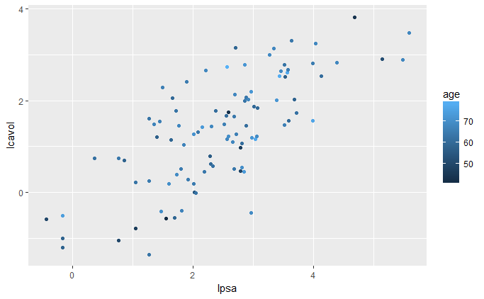

```r
ggplot(data=Prostate) + aes(x=lpsa, y=lcavol, color=age) + geom_point()
```

Le cancer semble effetivement corrélé à l’antigène, et ce quel que soit l’âge.

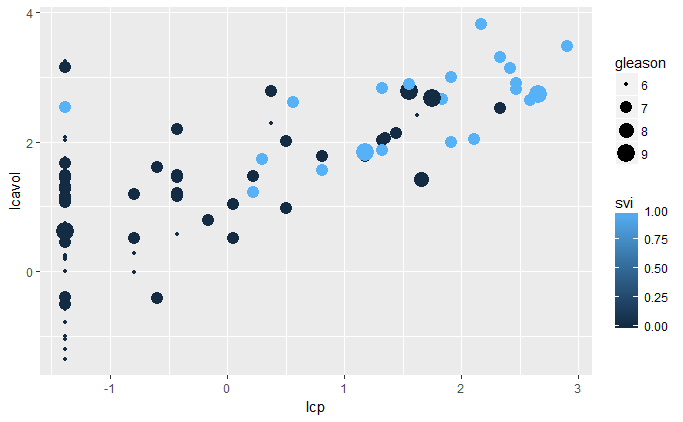

```r
ggplot(data=Prostate) + aes(x=lcp, y=lcavol, color=svi, size=gleason) + geom_point()
```

On remarque également une corrélation entre le log de la `capsular penetration` et la taille du cancer. EN outre, les personne a faible score de gleason ont n’ont pas d’invasion de la vésicule seminale ; et sont moins propices au gros cancers.

### PCA

```r
library(ade4)
pca = dudi.pca(Prostate %>% select(lcavol,lweight,age,lbph,lcp,lpsa))
```

```
Select the number of axes:
```

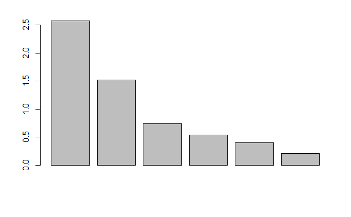

```r
2
```

```r
pve <- 100 * pca$eig/sum(pca$eig)
cumsum(pve)
```

```
[1]  42.95815  68.29755  80.69772  89.72920  96.44372 100.00000
```

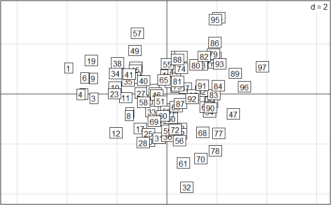

```r
s.label(pca$li, xax = 1, yax = 2)
```

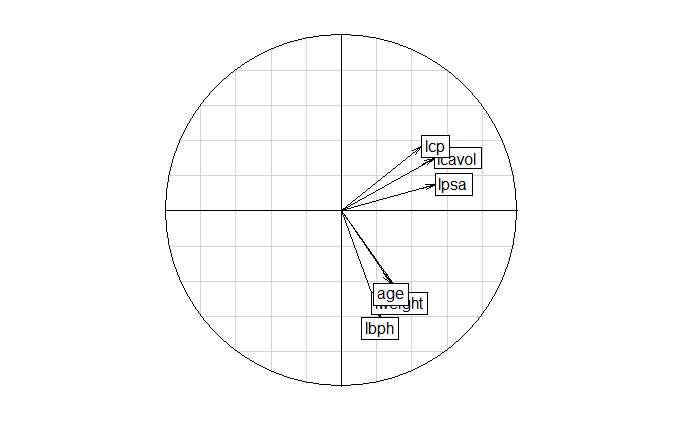

```r
s.corcircle(dfxy = pca$c1)
```

Il n’y a pas d’anomalie notable ; et on remarque principalement deux caractéristiques sont extraites, couvrant 68% de l’information seulement: l’antigène et la capsular penetration sont fortement lié à la taille du cancer, quand l’age, le poid de la prostate et la `benign prostatic hyperplasia amount` ne sont pas reliés significativement. On remarque que les 90% de variances ne sont reproduite qu’avec plus de 4 axes, ce qui montre que l’on a affaire à des données peu corellées.

```r
ind.test = sample(nrow(Prostate), size = round(nrow(Prostate)*0.25))
Prostate.app = Prostate[-ind.test,]
Prostate.test = Prostate[c(ind.test),]
modlin = lm(lpsa ~ ., data = Prostate.app)
summary(modlin)
```

```
Call:
lm(formula = lpsa ~ ., data = Prostate.app)

Residuals:
     Min       1Q   Median       3Q      Max
-1.61568 -0.46823 -0.05194  0.36447  1.65938

Coefficients:
             Estimate Std. Error t value Pr(>|t|)
(Intercept)  0.519717   1.468553   0.354  0.72458
lcavol       0.589068   0.110671   5.323  1.4e-06 ***
lweight      0.387802   0.193772   2.001  0.04960 *
age         -0.015507   0.013066  -1.187  0.23968
lbph         0.108928   0.071991   1.513  0.13518
svi          0.788945   0.285840   2.760  0.00753 **
lcp         -0.091108   0.102545  -0.888  0.37761
gleason      0.071919   0.188413   0.382  0.70394
pgg45        0.003346   0.005148   0.650  0.51808
---
Signif. codes:  0 *** 0.001 ** 0.01 * 0.05 . 0.1   1

Residual standard error: 0.7407 on 64 degrees of freedom
Multiple R-squared:  0.6434,    Adjusted R-squared:  0.5988
F-statistic: 14.43 on 8 and 64 DF,  p-value: 8.585e-12
```

Les valeurs significatives sont lcavol, lweight et svi.

2. L’erreur standard sur les résidu est 0,7407
3. R^2 = 0,6434

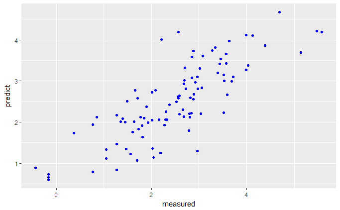

```r
mesure_predict=data.frame(predict = predict(modlin, Prostate), measured = Prostate$lpsa)
ggplot(data=mesure_predict) + aes(y=predict, x=measured) + geom_point(color="blue")
```

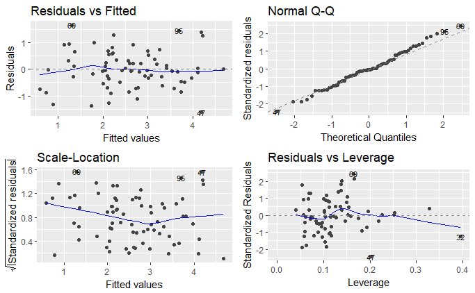

```r
autoplot(modlin, label.size = 3)
```

On a une p-value du teste de F 8,58.10^-12 (probabilité d’obtenir ce résultat sous l’hypothèse nulle) : on a donc un modèle significatif.

```r
library(MASS)
modselect_b = stepAIC(modlin, ~., trace=TRUE, direction=c("backward"))
```

```
Start:  AIC=-35.43
lpsa ~ lcavol + lweight + age + lbph + svi + lcp + gleason +
    pgg45

          Df Sum of Sq    RSS     AIC
- gleason  1    0.0799 35.194 -37.259
- pgg45    1    0.2317 35.346 -36.945
- lcp      1    0.4331 35.547 -36.530
- age      1    0.7728 35.887 -35.836
<none>                 35.114 -35.425
- lbph     1    1.2561 36.370 -34.860
- lweight  1    2.1976 37.312 -32.994
- svi      1    4.1797 39.294 -29.215
- lcavol   1   15.5441 50.658 -10.671

Step:  AIC=-37.26
lpsa ~ lcavol + lweight + age + lbph + svi + lcp + pgg45

          Df Sum of Sq    RSS     AIC
- lcp      1    0.4146 35.609 -38.404
- pgg45    1    0.6585 35.853 -37.906
- age      1    0.7214 35.916 -37.778
<none>                 35.194 -37.259
- lbph     1    1.2148 36.409 -36.782
- lweight  1    2.1585 37.353 -34.914
- svi      1    4.1241 39.318 -31.170
- lcavol   1   17.0423 52.236 -10.432

Step:  AIC=-38.4
lpsa ~ lcavol + lweight + age + lbph + svi + pgg45

          Df Sum of Sq    RSS     AIC
- pgg45    1    0.3345 35.943 -39.722
- age      1    0.6135 36.222 -39.157
<none>                 35.609 -38.404
- lbph     1    1.3477 36.956 -37.693
- lweight  1    2.1159 37.725 -36.191
- svi      1    3.7318 39.341 -33.129
- lcavol   1   18.5370 54.146  -9.811

Step:  AIC=-39.72
lpsa ~ lcavol + lweight + age + lbph + svi

          Df Sum of Sq    RSS     AIC
- age      1    0.4287 36.372 -40.856
<none>                 35.943 -39.722
- lbph     1    1.4654 37.409 -38.805
- lweight  1    1.9348 37.878 -37.894
- svi      1    4.4080 40.351 -33.277
- lcavol   1   21.6713 57.615  -7.278

Step:  AIC=-40.86
lpsa ~ lcavol + lweight + lbph + svi

          Df Sum of Sq    RSS     AIC
<none>                 36.372 -40.856
- lbph     1    1.1276 37.500 -40.627
- lweight  1    1.7255 38.098 -39.473
- svi      1    4.1986 40.571 -34.881
- lcavol   1   21.2561 57.628  -9.261
```

```r
summary(modselect_b)
```

```
Call:
lm(formula = lpsa ~ lcavol + lweight + lbph + svi, data = Prostate.app)

Residuals:
     Min       1Q   Median       3Q      Max
-1.56087 -0.49370 -0.05612  0.53343  1.51006

Coefficients:
            Estimate Std. Error t value Pr(>|t|)
(Intercept)  0.35609    0.68345   0.521  0.60405
lcavol       0.56826    0.09014   6.304 2.48e-08 ***
lweight      0.33688    0.18756   1.796  0.07692 .
lbph         0.09739    0.06707   1.452  0.15111
svi          0.69442    0.24786   2.802  0.00661 **
---
Signif. codes:  0 *** 0.001 ** 0.01 * 0.05 . 0.1   1

Residual standard error: 0.7314 on 68 degrees of freedom
Multiple R-squared:  0.6306,    Adjusted R-squared:  0.6089
F-statistic: 29.02 on 4 and 68 DF,  p-value: 4.421e-14
```

```r
mod0 = lm(lpsa ~ 1, data = Prostate)
modselect_f = stepAIC(mod0, lpsa ~ lcavol + lweight + age + lbph + svi +
lcp + gleason + pgg45, data = Prostate,
trace = TRUE, direction=c("forward"))
```

```
Start:  AIC=28.84
lpsa ~ 1

          Df Sum of Sq     RSS     AIC
+ lcavol   1    69.003  58.915 -44.366
+ svi      1    41.011  86.907  -6.658
+ lcp      1    38.528  89.389  -3.926
+ pgg45    1    22.814 105.103  11.783
+ gleason  1    17.416 110.502  16.641
+ lweight  1    16.041 111.877  17.841
+ lbph     1     4.136 123.782  27.650
+ age      1     3.679 124.239  28.007
<none>                 127.918  28.838

Step:  AIC=-44.37
lpsa ~ lcavol

          Df Sum of Sq    RSS     AIC
+ lweight  1    5.9484 52.966 -52.690
+ svi      1    5.2375 53.677 -51.397
+ lbph     1    3.2658 55.649 -47.898
+ pgg45    1    1.6980 57.217 -45.203
<none>                 58.915 -44.366
+ lcp      1    0.6562 58.259 -43.452
+ gleason  1    0.4156 58.499 -43.053
+ age      1    0.0025 58.912 -42.370

Step:  AIC=-52.69
lpsa ~ lcavol + lweight

          Df Sum of Sq    RSS     AIC
+ svi      1    5.1814 47.785 -60.676
+ pgg45    1    1.9489 51.017 -54.327
<none>                 52.966 -52.690
+ lcp      1    0.8371 52.129 -52.235
+ gleason  1    0.7810 52.185 -52.131
+ lbph     1    0.6751 52.291 -51.935
+ age      1    0.4200 52.546 -51.462

Step:  AIC=-60.68
```

[output cut: 13 more lines]

```
          Df Sum of Sq    RSS     AIC
+ age      1   0.95925 45.526 -61.374
<none>                 46.485 -61.352
+ pgg45    1   0.35332 46.132 -60.092
+ gleason  1   0.21254 46.272 -59.796
+ lcp      1   0.10230 46.383 -59.565

Step:  AIC=-61.37
lpsa ~ lcavol + lweight + svi + lbph + age

          Df Sum of Sq    RSS     AIC
<none>                 45.526 -61.374
+ pgg45    1   0.65896 44.867 -60.788
+ gleason  1   0.45598 45.070 -60.351
+ lcp      1   0.12927 45.396 -59.650
```

```r
summary(modselect_f)
```

```
Call:
lm(formula = lpsa ~ lcavol + lweight + svi + lbph + age, data = Prostate)

Residuals:
     Min       1Q   Median       3Q      Max
-1.83506 -0.39395  0.00412  0.46336  1.57887

Coefficients:
            Estimate Std. Error t value Pr(>|t|)
(Intercept)  0.95102    0.83174   1.143 0.255870
lcavol       0.56561    0.07459   7.583 2.77e-11 ***
lweight      0.42369    0.16687   2.539 0.012815 *
svi          0.72096    0.20902   3.449 0.000854 ***
lbph         0.11184    0.05805   1.927 0.057160 .
age         -0.01489    0.01075  -1.385 0.169527
---
Signif. codes:  0 *** 0.001 ** 0.01 * 0.05 . 0.1   1

Residual standard error: 0.7073 on 91 degrees of freedom
Multiple R-squared:  0.6441,    Adjusted R-squared:  0.6245
F-statistic: 32.94 on 5 and 91 DF,  p-value: < 2.2e-16
```

```r
modselect = stepAIC(modlin, ~., trace = TRUE, direction = c("both"))
```

```
Start:  AIC=-35.43
lpsa ~ lcavol + lweight + age + lbph + svi + lcp + gleason +
    pgg45

          Df Sum of Sq    RSS     AIC
- gleason  1    0.0799 35.194 -37.259
- pgg45    1    0.2317 35.346 -36.945
- lcp      1    0.4331 35.547 -36.530
- age      1    0.7728 35.887 -35.836
<none>                 35.114 -35.425
- lbph     1    1.2561 36.370 -34.860
- lweight  1    2.1976 37.312 -32.994
- svi      1    4.1797 39.294 -29.215
- lcavol   1   15.5441 50.658 -10.671

Step:  AIC=-37.26
lpsa ~ lcavol + lweight + age + lbph + svi + lcp + pgg45

          Df Sum of Sq    RSS     AIC
- lcp      1    0.4146 35.609 -38.404
- pgg45    1    0.6585 35.853 -37.906
- age      1    0.7214 35.916 -37.778
<none>                 35.194 -37.259
- lbph     1    1.2148 36.409 -36.782
+ gleason  1    0.0799 35.114 -35.425
- lweight  1    2.1585 37.353 -34.914
- svi      1    4.1241 39.318 -31.170
- lcavol   1   17.0423 52.236 -10.432

Step:  AIC=-38.4
lpsa ~ lcavol + lweight + age + lbph + svi + pgg45

          Df Sum of Sq    RSS     AIC
- pgg45    1    0.3345 35.943 -39.722
- age      1    0.6135 36.222 -39.157
<none>                 35.609 -38.404
- lbph     1    1.3477 36.956 -37.693
+ lcp      1    0.4146 35.194 -37.259
+ gleason  1    0.0615 35.547 -36.530
- lweight  1    2.1159 37.725 -36.191
```

[output cut: 15 more lines]

```
- lcavol   1   21.6713 57.615  -7.278

Step:  AIC=-40.86
lpsa ~ lcavol + lweight + lbph + svi

          Df Sum of Sq    RSS     AIC
<none>                 36.372 -40.856
- lbph     1    1.1276 37.500 -40.627
+ age      1    0.4287 35.943 -39.722
- lweight  1    1.7255 38.098 -39.473
+ pgg45    1    0.1497 36.222 -39.157
+ gleason  1    0.1377 36.234 -39.133
+ lcp      1    0.1006 36.271 -39.058
- svi      1    4.1986 40.571 -34.881
- lcavol   1   21.2561 57.628  -9.261
```

```r
#both est loption par défaut
summary(modselect)
```

```
Call:
lm(formula = lpsa ~ lcavol + lweight + lbph + svi, data = Prostate.app)

Residuals:
     Min       1Q   Median       3Q      Max
-1.56087 -0.49370 -0.05612  0.53343  1.51006

Coefficients:
            Estimate Std. Error t value Pr(>|t|)
(Intercept)  0.35609    0.68345   0.521  0.60405
lcavol       0.56826    0.09014   6.304 2.48e-08 ***
lweight      0.33688    0.18756   1.796  0.07692 .
lbph         0.09739    0.06707   1.452  0.15111
svi          0.69442    0.24786   2.802  0.00661 **
---
Signif. codes:  0 *** 0.001 ** 0.01 * 0.05 . 0.1   1

Residual standard error: 0.7314 on 68 degrees of freedom
Multiple R-squared:  0.6306,    Adjusted R-squared:  0.6089
F-statistic: 29.02 on 4 and 68 DF,  p-value: 4.421e-14
```

```r
modselect_BIC = stepAIC(modlin, ~., trace = TRUE, direction = c("both"),
k = log(length(Prostate$lpsa)))
```

```
Start:  AIC=-12.25
lpsa ~ lcavol + lweight + age + lbph + svi + lcp + gleason +
    pgg45

          Df Sum of Sq    RSS      AIC
- gleason  1    0.0799 35.194 -16.6616
- pgg45    1    0.2317 35.346 -16.3474
- lcp      1    0.4331 35.547 -15.9327
- age      1    0.7728 35.887 -15.2384
- lbph     1    1.2561 36.370 -14.2619
- lweight  1    2.1976 37.312 -12.3963
<none>                 35.114 -12.2529
- svi      1    4.1797 39.294  -8.6177
- lcavol   1   15.5441 50.658   9.9267

Step:  AIC=-16.66
lpsa ~ lcavol + lweight + age + lbph + svi + lcp + pgg45

          Df Sum of Sq    RSS      AIC
- lcp      1    0.4146 35.609 -20.3813
- pgg45    1    0.6585 35.853 -19.8831
- age      1    0.7214 35.916 -19.7552
- lbph     1    1.2148 36.409 -18.7590
- lweight  1    2.1585 37.353 -16.8910
<none>                 35.194 -16.6616
- svi      1    4.1241 39.318 -13.1473
+ gleason  1    0.0799 35.114 -12.2529
- lcavol   1   17.0423 52.236   7.5914

Step:  AIC=-20.38
lpsa ~ lcavol + lweight + age + lbph + svi + pgg45

          Df Sum of Sq    RSS      AIC
- pgg45    1    0.3345 35.943 -24.2734
- age      1    0.6135 36.222 -23.7091
- lbph     1    1.3477 36.956 -22.2442
- lweight  1    2.1159 37.725 -20.7422
<none>                 35.609 -20.3813
- svi      1    3.7318 39.341 -17.6805
+ lcp      1    0.4146 35.194 -16.6616
```

[output cut: 29 more lines]

```
- lcavol   1   21.2561 57.628   1.038

Step:  AIC=-30.33
lpsa ~ lcavol + lweight + svi

          Df Sum of Sq    RSS      AIC
<none>                 37.500 -30.3285
- svi      1    3.5485 41.048 -28.3029
+ lbph     1    1.1276 36.372 -27.9827
- lweight  1    3.9222 41.422 -27.6415
+ pgg45    1    0.3064 37.193 -26.3528
+ gleason  1    0.2019 37.298 -26.1478
+ lcp      1    0.1236 37.376 -25.9948
+ age      1    0.0909 37.409 -25.9311
- lcavol   1   22.4583 59.958  -0.6435
```

```r
summary(modselect_BIC)
```

```
Call:
lm(formula = lpsa ~ lcavol + lweight + svi, data = Prostate.app)

Residuals:
     Min       1Q   Median       3Q      Max
-1.55835 -0.48983  0.04649  0.55781  1.52588

Coefficients:
            Estimate Std. Error t value Pr(>|t|)
(Intercept) -0.07332    0.62108  -0.118  0.90637
lcavol       0.58123    0.09042   6.428 1.42e-08 ***
lweight      0.45639    0.16989   2.686  0.00904 **
svi          0.62716    0.24544   2.555  0.01282 *
---
Signif. codes:  0 *** 0.001 ** 0.01 * 0.05 . 0.1   1

Residual standard error: 0.7372 on 69 degrees of freedom
Multiple R-squared:  0.6192,    Adjusted R-squared:  0.6026
F-statistic: 37.39 on 3 and 69 DF,  p-value: 1.825e-14
```

L’AIC forward est le meilleur choix, il réalise à la fois le minimum de l’AIC mais aussi le maximum du R^2 ajusté et le minimum de la p-valeur de l’hypothèse F.

```r
sum(abs(predict(modlin, Prostate.test)-Prostate.test$lpsa))
```

```
[1] 11.25975
```

```r
sum(abs(predict(modselect_b, Prostate.test)-Prostate.test$lpsa))
```

```
[1] 11.35384
```

```r
sum(abs(predict(modselect_f, Prostate.test)-Prostate.test$lpsa))
```

```
[1] 11.07186
```

```r
sum(abs(predict(modselect, Prostate.test)-Prostate.test$lpsa))
```

```
[1] 11.35384
```

```r
sum(abs(predict(modselect_BIC, Prostate.test)-Prostate.test$lpsa))
```

```
[1] 11.85234
```

On trouve sans surprise une meilleure erreur de reconstruction pour l’AIC forward.